# informe

Pedro Luis Boll Lugo

9 de noviembre de 2016

## Informe de proyecto de Mineria de Datos

Instalación:

Para poder correr este proyecto de manera correcta es necesario tener instalado los lenguajes de programacion Python en su version 2.X (preferiblemente 2.7) y el lenguaje de programación R.

Usando un sistema operativo linux basado en debian, esto se hace de la siguiente forma:

```
    sudo apt-get install python r-base
```

Una vez instalados los lenguajes de programacion utilizado, se recomienda utilizar spyder como IDE para desarrollar en Python, RStudio como IDE para desarrollar en R y la utilizacion de ciertas librerias, que permitiran el funcionamiento del prooyecto.

Para el caso de las librerias de Python y el conjunto de librerias utilizadas debemos realizar los siguientes pasos en una terminal:

```
    sudo pip install virtualenv virtualenwrapper spyder
```

o bien podemos hacer

```
    sudo apt-get install python-dev python-pip python-virtualenv python-virtuaenvwrapper
```

Para crear y usar los enviroments de Python ademas necesitamos tambien configurar el interprete de ordenes, por lo que hacemos el comando

```
    nano ~/.bashrc
```

y agregamos al final del archivo

```
    export WORKON_HOME=$HOME/.virtualenvs
    export PROJECT_HOME=$HOME/Devel
    source /usr/local/bin/virtualenvwrapper.sh
```

Con ello podemos crear entornos con librerias de python sin que se afecten el entorno general de python. Procedemos a crear un enviroment, activarlo y bajar las librerias necesarias para la ejecucion de los scripts de python. Esto lo hacemos con los comandos siguientes:

```
    mkvirtualenv mineria
    workon mineria
    pip install scipy numpy pandas nltk
```

una vez instalados las librerias, procedemos a descargar el soporte para la libreria nltk (que hace el procesado del lenguaje natural en los textos) de la siguiente forma:

abriendo un shell de python escribimos:

```
    nltk.download()
```

Vamos a la pestaña all y le damos click en el boton de descargar. Despues de descargar el soporte podemos cerrar la consola, habiendo terminado la configuracion del entorno Python.

Para el Script en R podemos descargar el instalador de RStudio del siguiente link: https://www.rstudio.com/products/rstudio/download/

Una vez descargado e instalado podemos proceder abrir el IDE.En la pestaña de consola procedemos a instalar las librerias necesarias

```
    install.packages(c('arules','arulesViz'))
```

Si durante la instalaccion de la libreria arulesViz ocurre un error entonces correr el siguiente comando:

```
   sudo apt-get install libcurl4-gnutls-dev
```

Listo. Ya podemos comenzar a detallar la solucion del problema.

## Problema

Se requiere una solucion automatizada de reconocimiento del area de conocimiento de una tesis, haciendo uso de las palabras clave que podamos conseguir de los mismos. Para ello se provee de un conjunto de datos con los titulos, descripciones, palabras clave y la mencion de varios cientos de tesis.

## Solución

Se plantea que usando ese conjunto de datos de tesis, se cree una solucion haciendo uso de un proceso de descubrimiento de conocimiento (KDD) generando un modelo a traves de mineria de datos, para que dadas las palabras clave de una tesis, poder clasifcarla de la mejor manera posible.

El conjunto dado posee 4 variables distintas, todas nominales, las cuales consiste en el titulo de la tesis, la descripcion y la mencion de la tesis. Existe un problema que se observa al ver que la mayoria de las tesis posee incosistencias del tipo de errores ortograficos, la falta de datos, especialemerte en la columna de palabras clave que nos hacen imposible determinar cuando una tesis pertenece a una determinada area.

En un primer momento, realizaremos el proceso de preprocesamiento de estos datos utilizando el script de Python proyecto.py, con el que se ataca la problematica de la incosistencia de la data. Haciendo uso de la libreria nltk para el procesamiento de texto y lenguaje natural y haciendo uso de la descripcion de la tesis obtenemos las palabras mas relevantes y comunes de las mismas. Estos datos son guardados en la columna correspondiente y finalmente todos los datos son impresos en dos archivos auxiliares .csv separados por coma. El archivo salida.csv corresponde a los datos ya operados y completados, mientras que el archivo trans.csv asocia cada palabra clave de una tesis con su respectiva mención.

Ahora pasamos a la generacion del modelo, usando el lenguaje de programacion R.

Lo primero que se realiza es el import de las librerias arules y arulesViz, que fueron creadas para obtener reglas de asocación a traves de un conjunto de datos transaccional. Eso se hace a traves de los comandos:

```r
    setwd("~/Universidad/Mineria de Datos/proyectoMineriaDeDatos/")
    library(arules)
```

```r
    library(arulesViz)
```

Cabe destacar que se debe cambiar el directorio de trabajo mostrado anteriormente por el directorio en donde se encuentra el proyecto. El siguiente paso es leer los conjuntos de datos preprocesados.

```r
    df <- read.csv("datos/trans.csv")
    dataset <- read.csv("datos/salida.csv")
```

Luego de obtenido los datos, podemos observar que en el dataframe existen una cantidad de palabras vacias, es decir, que no aportan nada al analisis. Por lo que creamos una lista diccionario para poder excluirlas de las palabras clave verdaderas.

```r
diccionario = c('central','consiste','herramienta','manejo','ello','permitan',
                '20','a','adémas','de','manera','en','forma','cada','facultad',
                'más','ser','y','debido','través','mayor','ciencias','también',
                'ucv','uso','cabo','vez','puede','pueden','éL','la','lo','los',
                'las','así','el','del','una','un','desarrollo','trabajo','para',
                'sistema','gran', 'docentes','ejemplo','está','launiversidad',
                'usando','lafacultad','poder','tipo','según','debe','diferentes',
                'dela','profesores','dentro','punto','necesidades','escuela',
                'bajo','hace','utilizando','postgrado','mismos','estudios','hacia',
                'tener','permita','fin','venezuela','presenta','personal',
                'presente','además','grado'
                )
```

Ahora bien, quitamos las palabras vacias del resto

```r
trx <- df
trx <- trx[ ! trx$keyword %in% diccionario,]
```

Y volvemos el dataframe en un conjunto de “transacciones”

```r
trx <- split(trx$mencion,trx$keyword)
trx <- as(trx,"transactions")
```

Observemos el resultado de cada par palabra clave con mención

```r
inspect(trx)
```

```
##        items             transactionID
## [1]    {3}               10000
## [2]    {3}               1000000
## [3]    {11}              10metros
## [4]    {11}              10veces
## [5]    {11}              1mbpsel
## [6]    {11}              1xrtt
## [7]    {}                20
## [8]    {3}               2000advance
## [9]    {11}              2277000022
## [10]   {2}               24
## [11]   {7}               25
## [12]   {2}               3
## [13]   {2}               3casos
## [14]   {5}               3d
```

[output cut: 3172 more lines]

Y observemos alguna informacion relevante de los mismos

```r
trx
```

```
## transactions in sparse format with
##  3186 transactions (rows) and
##  11 items (columns)
```

```r
colnames(trx)
```

```
##  [1] "1"  "2"  "3"  "4"  "5"  "6"  "7"  "8"  "9"  "10" "11"
```

Ahora generemos la serie de reglas que nos diran los criterios para asociar las palabras clave a una determinada mencion. Para ellos hacemos uso del algoritmo apriori que viene en la libreria arules.

```r
reglas <- apriori(trx, parameter=list(support=0.0005, confidence = 0.0125,minlen=2))
```

```
## Apriori
##
## Parameter specification:
##  confidence minval smax arem  aval originalSupport maxtime support minlen
##      0.0125    0.1    1 none FALSE            TRUE       5   5e-04      2
##  maxlen target   ext
##      10  rules FALSE
##
## Algorithmic control:
##  filter tree heap memopt load sort verbose
##     0.1 TRUE TRUE  FALSE TRUE    2    TRUE
##
## Absolute minimum support count: 1
##
## set item appearances ...[0 item(s)] done [0.00s].
## set transactions ...[11 item(s), 3186 transaction(s)] done [0.00s].
## sorting and recoding items ... [11 item(s)] done [0.00s].
## creating transaction tree ... done [0.00s].
## checking subsets of size 1 2 3 4 5 6 done [0.00s].
## writing ... [636 rule(s)] done [0.00s].
## creating S4 object  ... done [0.00s].
```

Observemos las reglas que se han generado en el proceso:

```r
summary(reglas)
```

```
## set of 636 rules
##
## rule length distribution (lhs + rhs):sizes
##   2   3   4   5   6
##  63 189 224 130  30
##
##    Min. 1st Qu.  Median    Mean 3rd Qu.    Max.
##   2.000   3.000   4.000   3.803   5.000   6.000
##
## summary of quality measures:
##     support            confidence           lift
##  Min.   :0.0006278   Min.   :0.01282   Min.   :  0.1906
##  1st Qu.:0.0006278   1st Qu.:0.22118   1st Qu.:  2.3585
##  Median :0.0009416   Median :0.63558   Median :  3.3466
##  Mean   :0.0044298   Mean   :0.58266   Mean   :  6.9525
##  3rd Qu.:0.0034526   3rd Qu.:1.00000   3rd Qu.:  5.3756
##  Max.   :0.0816070   Max.   :1.00000   Max.   :144.8182
##
## mining info:
##  data ntransactions support confidence
##   trx          3186   5e-04     0.0125
```

```r
inspect(reglas)
```

```
##       lhs              rhs  support      confidence lift
## [1]   {1}           => {8}  0.0006277464 1.00000000  16.8571429
## [2]   {1}           => {7}  0.0006277464 1.00000000   4.8272727
## [3]   {1}           => {11} 0.0006277464 1.00000000   3.3466387
## [4]   {1}           => {2}  0.0006277464 1.00000000   3.5088106
## [5]   {1}           => {3}  0.0006277464 1.00000000   2.6683417
## [6]   {9}           => {6}  0.0006277464 0.10000000   2.0423077
## [7]   {6}           => {9}  0.0006277464 0.01282051   2.0423077
## [8]   {9}           => {8}  0.0006277464 0.10000000   1.6857143
## [9]   {9}           => {11} 0.0006277464 0.10000000   0.3346639
## [10]  {9}           => {2}  0.0009416196 0.15000000   0.5263216
## [11]  {9}           => {3}  0.0006277464 0.10000000   0.2668342
## [12]  {4}           => {6}  0.0006277464 0.07142857   1.4587912
## [13]  {6}           => {4}  0.0006277464 0.01282051   1.4587912
## [14]  {4}           => {7}  0.0015693660 0.17857143   0.8620130
```

[output cut: 622 more lines]

Como podemos ver, tenemos un conjunto de reglas importante para poder tomar decisiones referente a las palabras clave y las menciones que podrian perteneces. Veamos las 25 reglas con mayor confianza del grupo

```r
reglas <-sort(reglas, by="confidence", decreasing=TRUE) # ordena regla
inspect(head(reglas,25))
```

```
##      lhs       rhs  support      confidence lift
## [1]  {1}    => {8}  0.0006277464 1          16.857143
## [2]  {1}    => {7}  0.0006277464 1           4.827273
## [3]  {1}    => {11} 0.0006277464 1           3.346639
## [4]  {1}    => {2}  0.0006277464 1           3.508811
## [5]  {1}    => {3}  0.0006277464 1           2.668342
## [6]  {1,8}  => {7}  0.0006277464 1           4.827273
## [7]  {1,7}  => {8}  0.0006277464 1          16.857143
## [8]  {1,8}  => {11} 0.0006277464 1           3.346639
## [9]  {1,11} => {8}  0.0006277464 1          16.857143
## [10] {1,8}  => {2}  0.0006277464 1           3.508811
## [11] {1,2}  => {8}  0.0006277464 1          16.857143
## [12] {1,8}  => {3}  0.0006277464 1           2.668342
## [13] {1,3}  => {8}  0.0006277464 1          16.857143
## [14] {1,7}  => {11} 0.0006277464 1           3.346639
## [15] {1,11} => {7}  0.0006277464 1           4.827273
## [16] {1,7}  => {2}  0.0006277464 1           3.508811
## [17] {1,2}  => {7}  0.0006277464 1           4.827273
## [18] {1,7}  => {3}  0.0006277464 1           2.668342
## [19] {1,3}  => {7}  0.0006277464 1           4.827273
## [20] {1,11} => {2}  0.0006277464 1           3.508811
## [21] {1,2}  => {11} 0.0006277464 1           3.346639
## [22] {1,11} => {3}  0.0006277464 1           2.668342
## [23] {1,3}  => {11} 0.0006277464 1           3.346639
## [24] {1,2}  => {3}  0.0006277464 1           2.668342
## [25] {1,3}  => {2}  0.0006277464 1           3.508811
```

Con estas reglas podemos crear un script que dada la aparicion de esas palabras claves, clasificar una nueva tesis en una determinada mención. Graficamente se vera de la siguiente manera:

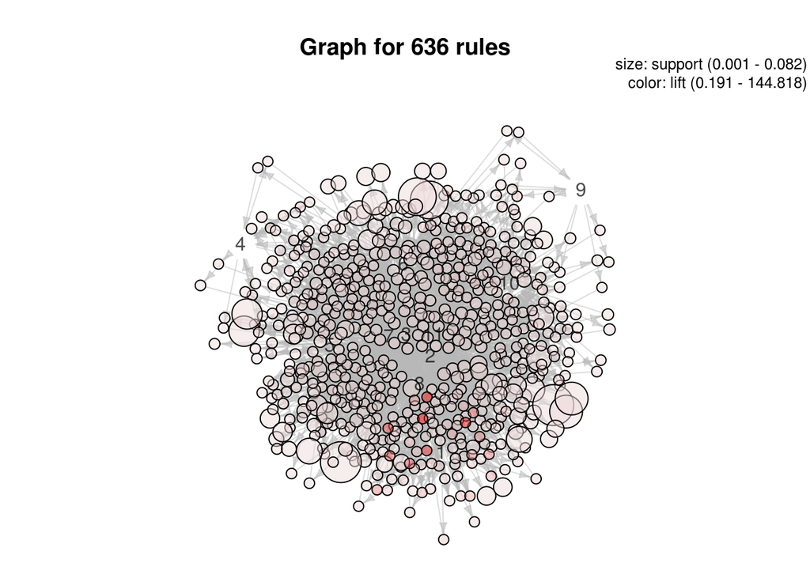